# Death injury data Project

## By\ Tamer Mostafa Abo_zeid

This dataset is obtained from Kaggle website. It describes injury mortality in the United States beginning from 1999 to 2016. Data are based on informations from all resident death certificates filed in the 50 states and the District of Columbia. Circumstances of an injury death: intent of injury and mechanism of injury are included. Source: https://catalog.data.gov/dataset/nchs-injury-mortality-united-states

|  | Year | Sex | Age group (years) | Race | Injury mechanism | Injury intent | Deaths | Population | Age Specific Rate | Age Specific Rate Standard Error | Age Specific Rate Lower Confidence Limit | Age Specific Rate Upper Confidence Limit | Age Adjusted Rate | Age Adjusted Rate Standard Error | Age Adjusted Rate Lower Confidence Limit | Age Adjusted Rate Upper Confidence Limit | Unit |
| --- | --- | --- | --- | --- | --- | --- | --- | --- | --- | --- | --- | --- | --- | --- | --- | --- | --- |
| 0 | 2016 | Both sexes | All Ages | All races | All Mechanisms | All Intentions | 231991 | 323127513 | 71.80 | 0.15 | 71.50 | 72.09 | 68.98 | 0.15 | 68.70 | 69.27 | per 100,000 population |
| 1 | 2015 | Both sexes | All Ages | All races | All Mechanisms | All Intentions | 214008 | 321418820 | 66.58 | 0.14 | 66.30 | 66.86 | 63.87 | 0.14 | 63.59 | 64.14 | per 100,000 population |
| 2 | 2014 | Both sexes | All Ages | All races | All Mechanisms | All Intentions | 199752 | 318857056 | 62.65 | 0.14 | 62.37 | 62.92 | 60.13 | 0.14 | 59.86 | 60.40 | per 100,000 population |
| 3 | 2013 | Both sexes | All Ages | All races | All Mechanisms | All Intentions | 192945 | 316128839 | 61.03 | 0.14 | 60.76 | 61.31 | 58.77 | 0.14 | 58.51 | 59.04 | per 100,000 population |
| 4 | 2012 | Both sexes | All Ages | All races | All Mechanisms | All Intentions | 190385 | 313914040 | 60.65 | 0.14 | 60.38 | 60.92 | 58.70 | 0.14 | 58.43 | 58.96 | per 100,000 population |
| ... | ... | ... | ... | ... | ... | ... | ... | ... | ... | ... | ... | ... | ... | ... | ... | ... | ... |
| 98275 | 2003 | Female | 75+ | Hispanic | Unspecified | Legal intervention/war | 0 | 488417 | 0.00 | NaN | 0.00 | 0.00 | NaN | NaN | NaN | NaN | per 100,000 population |
| 98276 | 2002 | Female | 75+ | Hispanic | Unspecified | Legal intervention/war | 0 | 460962 | 0.00 | NaN | 0.00 | 0.00 | NaN | NaN | NaN | NaN | per 100,000 population |
| 98277 | 2001 | Female | 75+ | Hispanic | Unspecified | Legal intervention/war | 0 | 435880 | 0.00 | NaN | 0.00 | 0.00 | NaN | NaN | NaN | NaN | per 100,000 population |
| 98278 | 2000 | Female | 75+ | Hispanic | Unspecified | Legal intervention/war | 0 | 403973 | 0.00 | NaN | 0.00 | 0.00 | NaN | NaN | NaN | NaN | per 100,000 population |
| 98279 | 1999 | Female | 75+ | Hispanic | Unspecified | Legal intervention/war | 0 | 384422 | 0.00 | NaN | 0.00 | 0.00 | NaN | NaN | NaN | NaN | per 100,000 population |

98280 rows × 17 columns

```
<class 'pandas.core.frame.DataFrame'>
RangeIndex: 98280 entries, 0 to 98279
Data columns (total 17 columns):
 #   Column                                    Non-Null Count  Dtype
---  ------                                    --------------  -----
 0   Year                                      98280 non-null  int64
 1   Sex                                       98280 non-null  object
 2   Age group (years)                         98280 non-null  object
 3   Race                                      98280 non-null  object
 4   Injury mechanism                          98280 non-null  object
 5   Injury intent                             98280 non-null  object
 6   Deaths                                    98280 non-null  int64
 7   Population                                98280 non-null  int64
 8   Age Specific Rate                         98280 non-null  float64
 9   Age Specific Rate Standard Error          80093 non-null  float64
 10  Age Specific Rate Lower Confidence Limit  98280 non-null  float64
 11  Age Specific Rate Upper Confidence Limit  98280 non-null  float64
 12  Age Adjusted Rate                         14040 non-null  float64
 13  Age Adjusted Rate Standard Error          12759 non-null  float64
 14  Age Adjusted Rate Lower Confidence Limit  11748 non-null  float64
 15  Age Adjusted Rate Upper Confidence Limit  11748 non-null  float64
 16  Unit                                      98280 non-null  object
dtypes: float64(8), int64(3), object(6)
memory usage: 12.7+ MB
```

```
count     98280.000000
mean       1030.300346
std        5654.431217
min           0.000000
25%           2.000000
50%          26.000000
75%         235.000000
max      231991.000000
Name: Deaths, dtype: float64
```

| Injury intent | Year Age group (years) | 1999 | 2000 | 2001 | 2002 | 2003 | 2004 | 2005 | 2006 | 2007 | 2008 | 2009 | 2010 | 2011 | 2012 | 2013 | 2014 | 2015 | 2016 |
| --- | --- | --- | --- | --- | --- | --- | --- | --- | --- | --- | --- | --- | --- | --- | --- | --- | --- | --- | --- |
| All Intentions | 15–24 | 1252.638889 | 1276.777778 | 1313.500000 | 1370.722222 | 1372.694444 | 1384.000000 | 1413.083333 | 1457.305556 | 1427.916667 | 1319.861111 | 1203.694444 | 1202.250000 | 1208.916667 | 1192.888889 | 1158.388889 | 1167.472222 | 1262.138889 | 1374.666667 |
|  | 25–44 | 2637.888889 | 2620.500000 | 2793.638889 | 2803.416667 | 2793.888889 | 2785.194444 | 2859.500000 | 2954.083333 | 2947.361111 | 2850.277778 | 2725.833333 | 2739.666667 | 2833.305556 | 2871.555556 | 2893.527778 | 3008.694444 | 3337.861111 | 3843.972222 |
|  | 45–64 | 1655.722222 | 1734.000000 | 1912.694444 | 2033.638889 | 2175.861111 | 2304.666667 | 2467.472222 | 2638.722222 | 2772.527778 | 2855.388889 | 2875.083333 | 2953.805556 | 3091.694444 | 3126.472222 | 3186.444444 | 3275.972222 | 3432.611111 | 3672.694444 |
|  | 65–74 | 617.083333 | 577.000000 | 596.583333 | 606.055556 | 599.111111 | 600.333333 | 632.916667 | 620.694444 | 643.833333 | 677.638889 | 686.055556 | 710.277778 | 756.638889 | 801.388889 | 846.861111 | 919.222222 | 979.250000 | 1055.361111 |
|  | 75+ | 1518.861111 | 1480.444444 | 1561.472222 | 1605.027778 | 1633.638889 | 1673.527778 | 1743.333333 | 1745.527778 | 1815.944444 | 1860.944444 | 1849.888889 | 1948.833333 | 2027.027778 | 2083.472222 | 2137.500000 | 2220.916667 | 2338.444444 | 2380.472222 |
|  | < 15 | 400.611111 | 392.888889 | 382.861111 | 372.333333 | 365.361111 | 373.666667 | 362.888889 | 353.777778 | 354.277778 | 334.583333 | 316.055556 | 305.527778 | 306.611111 | 299.611111 | 297.527778 | 291.361111 | 302.777778 | 309.361111 |
|  | All Ages | 8091.166667 | 8087.083333 | 8568.500000 | 8797.944444 | 8946.500000 | 9127.583333 | 9483.444444 | 9774.194444 | 9965.083333 | 9900.527778 | 9659.861111 | 9862.361111 | 10226.055556 | 10376.472222 | 10522.027778 | 10885.138889 | 11654.305556 | 12638.194444 |
| Homicide | 15–24 | 297.909091 | 294.242424 | 314.969697 | 310.030303 | 318.666667 | 303.272727 | 324.181818 | 339.787879 | 331.666667 | 315.090909 | 289.242424 | 279.090909 | 272.272727 | 275.878788 | 259.333333 | 249.151515 | 283.333333 | 309.272727 |
|  | 25–44 | 441.181818 | 439.030303 | 560.121212 | 458.242424 | 453.848485 | 445.424242 | 467.484848 | 461.000000 | 465.000000 | 447.757576 | 414.666667 | 399.454545 | 398.121212 | 418.848485 | 405.484848 | 402.969697 | 461.939394 | 521.030303 |
|  | 45–64 | 140.575758 | 146.848485 | 204.939394 | 163.000000 | 165.909091 | 170.454545 | 172.969697 | 190.242424 | 185.363636 | 185.575758 | 181.363636 | 181.030303 | 185.818182 | 189.303030 | 187.696970 | 182.333333 | 201.909091 | 210.272727 |
|  | 65–74 | 28.121212 | 26.242424 | 31.393939 | 24.848485 | 25.363636 | 26.393939 | 26.060606 | 23.636364 | 24.333333 | 27.242424 | 28.363636 | 26.787879 | 26.818182 | 29.696970 | 30.484848 | 32.636364 | 32.454545 | 34.272727 |
|  | 75+ | 24.000000 | 23.878788 | 24.939394 | 23.303030 | 25.090909 | 23.545455 | 23.575758 | 22.818182 | 20.787879 | 21.484848 | 22.818182 | 21.454545 | 23.000000 | 22.242424 | 23.636364 | 22.939394 | 23.848485 | 23.575758 |
|  | < 15 | 67.212121 | 64.121212 | 63.424242 | 63.636364 | 61.575758 | 61.272727 | 60.242424 | 64.848485 | 65.121212 | 63.636364 | 58.939394 | 56.787879 | 58.181818 | 55.848485 | 52.575758 | 52.727273 | 55.060606 | 53.242424 |
|  | All Ages | 1001.121212 | 995.727273 | 1201.333333 | 1045.000000 | 1052.424242 | 1031.969697 | 1075.484848 | 1103.242424 | 1093.484848 | 1061.181818 | 996.181818 | 965.545455 | 964.575758 | 991.969697 | 959.575758 | 943.060606 | 1058.757576 | 1151.787879 |
| Legal intervention/war | 15–24 | 5.458333 | 6.000000 | 7.333333 | 7.416667 | 7.625000 | 6.833333 | 7.166667 | 7.958333 | 8.208333 | 7.250000 | 6.333333 | 5.958333 | 8.333333 | 9.666667 | 8.125000 | 6.583333 | 7.125000 | 6.250000 |
|  | 25–44 | 20.875000 | 17.166667 | 18.083333 | 17.458333 | 20.541667 | 17.375000 | 19.625000 | 21.333333 | 18.791667 | 16.708333 | 15.833333 | 17.208333 | 18.958333 | 22.291667 | 22.416667 | 23.541667 | 22.083333 | 26.125000 |
|  | 45–64 | 6.083333 | 5.583333 | 6.208333 | 6.125000 | 6.125000 | 6.041667 | 7.416667 | 7.125000 | 7.333333 | 7.458333 | 9.541667 | 9.875000 | 11.375000 | 12.291667 | 10.791667 | 10.958333 | 12.541667 | 10.625000 |
|  | 65–74 | 0.833333 | 0.666667 | 0.833333 | 0.750000 | 0.500000 | 0.666667 | 0.750000 | 0.750000 | 0.500000 | 0.791667 | 1.166667 | 0.708333 | 1.291667 | 1.083333 | 1.250000 | 1.625000 | 0.916667 | 1.791667 |
|  | 75+ | 1.000000 | 1.000000 | 1.166667 | 1.000000 | 0.583333 | 1.666667 | 1.166667 | 0.500000 | 0.750000 | 1.375000 | 1.166667 | 0.333333 | 0.500000 | 0.916667 | 0.916667 | 0.333333 | 0.833333 | 0.833333 |
|  | < 15 | 0.083333 | 0.250000 | 0.000000 | 0.250000 | 0.166667 | 0.000000 | 0.083333 | 0.083333 | 0.083333 | 0.041667 | 0.250000 | 0.125000 | 0.083333 | 0.083333 | 0.083333 | 0.083333 | 0.000000 | 0.166667 |
|  | All Ages | 34.333333 | 30.666667 | 33.625000 | 33.000000 | 35.541667 | 32.583333 | 36.208333 | 37.750000 | 35.666667 | 33.625000 | 34.291667 | 34.208333 | 40.541667 | 46.333333 | 43.583333 | 43.125000 | 43.500000 | 45.791667 |
| Suicide | 15–24 | 229.848485 | 235.757576 | 234.424242 | 236.606061 | 234.818182 | 254.000000 | 248.030303 | 244.939394 | 242.272727 | 252.575758 | 255.545455 | 268.848485 | 283.545455 | 284.969697 | 285.272727 | 297.939394 | 319.666667 | 332.606061 |
|  | 25–44 | 687.484848 | 674.333333 | 695.666667 | 706.696970 | 692.393939 | 694.000000 | 684.151515 | 686.666667 | 710.939394 | 711.636364 | 710.696970 | 727.939394 | 751.090909 | 765.939394 | 760.727273 | 784.818182 | 819.727273 | 848.151515 |
|  | 45–64 | 476.000000 | 500.848485 | 553.848485 | 593.181818 | 617.515152 | 651.666667 | 669.848485 | 717.969697 | 768.424242 | 822.181818 | 859.151515 | 905.515152 | 917.666667 | 941.484848 | 939.969697 | 972.303030 | 981.545455 | 964.606061 |
|  | 65–74 | 148.090909 | 137.454545 | 145.303030 | 147.272727 | 139.454545 | 135.909091 | 140.484848 | 142.272727 | 146.212121 | 166.666667 | 174.242424 | 177.303030 | 189.727273 | 200.636364 | 226.545455 | 245.666667 | 250.818182 | 263.030303 |
|  | 75+ | 181.272727 | 180.848485 | 177.696970 | 184.939394 | 174.818182 | 174.969697 | 183.242424 | 174.969697 | 178.030303 | 177.151515 | 175.878788 | 180.666667 | 187.969697 | 196.606061 | 205.242424 | 214.575758 | 221.363636 | 227.303030 |
|  | < 15 | 14.454545 | 18.181818 | 16.333333 | 15.545455 | 14.757576 | 16.757576 | 15.818182 | 12.787879 | 10.636364 | 12.787879 | 15.666667 | 15.969697 | 16.848485 | 18.242424 | 23.181818 | 25.272727 | 24.151515 | 26.000000 |
|  | All Ages | 1737.939394 | 1747.757576 | 1823.909091 | 1884.727273 | 1874.030303 | 1927.787879 | 1941.909091 | 1979.939394 | 2056.848485 | 2143.151515 | 2191.787879 | 2276.545455 | 2347.363636 | 2408.060606 | 2441.212121 | 2540.818182 | 2617.454545 | 2661.818182 |
| Undetermined | 15–24 | 25.515152 | 21.969697 | 24.454545 | 29.090909 | 33.424242 | 29.939394 | 28.727273 | 35.727273 | 34.212121 | 29.575758 | 26.454545 | 27.000000 | 25.848485 | 27.121212 | 23.515152 | 23.242424 | 26.181818 | 29.393939 |
|  | 25–44 | 121.727273 | 117.515152 | 127.090909 | 140.363636 | 144.515152 | 131.030303 | 115.606061 | 124.787879 | 126.606061 | 113.666667 | 104.484848 | 103.181818 | 99.818182 | 97.424242 | 98.151515 | 97.151515 | 109.424242 | 129.181818 |
|  | 45–64 | 60.606061 | 63.909091 | 72.606061 | 87.393939 | 97.757576 | 102.121212 | 103.727273 | 110.454545 | 125.545455 | 123.969697 | 127.515152 | 120.393939 | 121.242424 | 116.151515 | 112.757576 | 113.757576 | 116.000000 | 134.090909 |
|  | 65–74 | 6.696970 | 6.060606 | 5.818182 | 8.151515 | 7.696970 | 9.121212 | 9.333333 | 9.606061 | 10.939394 | 9.969697 | 12.666667 | 11.515152 | 12.393939 | 15.272727 | 13.303030 | 16.030303 | 15.454545 | 19.484848 |
|  | 75+ | 9.121212 | 8.121212 | 8.969697 | 9.575758 | 8.848485 | 11.878788 | 10.757576 | 11.909091 | 11.909091 | 10.484848 | 13.030303 | 14.212121 | 12.454545 | 11.666667 | 12.424242 | 11.696970 | 12.333333 | 12.969697 |
|  | < 15 | 8.757576 | 9.545455 | 10.757576 | 13.151515 | 9.515152 | 12.727273 | 13.969697 | 12.000000 | 11.060606 | 13.545455 | 13.606061 | 15.272727 | 11.878788 | 12.848485 | 12.666667 | 11.333333 | 12.272727 | 14.515152 |
|  | All Ages | 233.333333 | 227.606061 | 250.454545 | 288.333333 | 302.545455 | 297.181818 | 282.575758 | 304.696970 | 320.636364 | 301.515152 | 297.818182 | 291.727273 | 283.727273 | 280.666667 | 272.939394 | 273.303030 | 291.696970 | 339.757576 |
| Unintentional | 15–24 | 737.416667 | 763.291667 | 777.861111 | 833.902778 | 825.847222 | 837.180556 | 852.083333 | 879.750000 | 864.972222 | 767.555556 | 675.833333 | 671.250000 | 670.166667 | 647.472222 | 632.194444 | 640.277778 | 680.638889 | 755.166667 |
|  | 25–44 | 1465.430556 | 1468.208333 | 1502.583333 | 1584.069444 | 1587.069444 | 1597.916667 | 1672.375000 | 1762.263889 | 1740.833333 | 1672.166667 | 1587.916667 | 1600.166667 | 1675.722222 | 1681.333333 | 1719.583333 | 1815.138889 | 2047.972222 | 2453.055556 |
|  | 45–64 | 1011.888889 | 1060.458333 | 1126.041667 | 1238.541667 | 1344.652778 | 1434.875000 | 1574.291667 | 1679.222222 | 1778.250000 | 1813.000000 | 1798.027778 | 1840.861111 | 1961.444444 | 1975.250000 | 2042.194444 | 2105.972222 | 2233.083333 | 2465.722222 |
|  | 65–74 | 427.527778 | 402.972222 | 409.819444 | 423.597222 | 423.527778 | 428.597222 | 454.597222 | 444.375000 | 477.138889 | 490.222222 | 487.944444 | 512.166667 | 545.916667 | 575.527778 | 598.222222 | 648.333333 | 704.805556 | 763.777778 |
|  | 75+ | 1175.736111 | 1154.638889 | 1225.416667 | 1276.277778 | 1311.597222 | 1359.527778 | 1419.861111 | 1430.305556 | 1622.277778 | 1668.333333 | 1655.027778 | 1750.305556 | 1821.888889 | 1871.555556 | 1915.694444 | 1992.250000 | 2101.805556 | 2138.055556 |
|  | < 15 | 315.208333 | 306.527778 | 298.041667 | 285.777778 | 284.652778 | 288.527778 | 278.333333 | 270.125000 | 274.638889 | 252.083333 | 235.027778 | 224.750000 | 226.888889 | 219.861111 | 216.416667 | 209.416667 | 218.916667 | 223.305556 |
|  | All Ages | 5137.986111 | 5159.500000 | 5344.750000 | 5646.111111 | 5780.500000 | 5950.513889 | 6254.180556 | 6468.791667 | 6759.583333 | 6664.416667 | 6441.694444 | 6600.222222 | 6903.000000 | 6971.611111 | 7125.388889 | 7412.305556 | 7988.055556 | 8800.416667 |

| Sex | Year Age group (years) | 1999 | 2000 | 2001 | 2002 | 2003 | 2004 | 2005 | 2006 | 2007 | 2008 | 2009 | 2010 | 2011 | 2012 | 2013 | 2014 | 2015 | 2016 |
| --- | --- | --- | --- | --- | --- | --- | --- | --- | --- | --- | --- | --- | --- | --- | --- | --- | --- | --- | --- |
| Both sexes | 15–24 | 692.546154 | 706.165385 | 726.169231 | 758.026923 | 759.219231 | 765.419231 | 781.146154 | 806.153846 | 790.846154 | 731.000000 | 666.661538 | 665.861538 | 669.553846 | 660.676923 | 641.569231 | 646.600000 | 699.030769 | 761.353846 |
|  | 25–44 | 1457.565385 | 1447.880769 | 1544.100000 | 1549.565385 | 1544.634615 | 1539.492308 | 1580.288462 | 1633.011538 | 1632.384615 | 1578.615385 | 1509.692308 | 1517.353846 | 1569.215385 | 1590.400000 | 1602.569231 | 1666.353846 | 1848.661538 | 2128.969231 |
|  | 45–64 | 911.746154 | 955.519231 | 1053.688462 | 1121.411538 | 1199.726923 | 1271.296154 | 1360.903846 | 1455.638462 | 1535.553846 | 1581.446154 | 1592.353846 | 1635.953846 | 1712.323077 | 1731.584615 | 1764.800000 | 1814.384615 | 1901.138462 | 2034.107692 |
|  | 65–74 | 335.861538 | 314.592308 | 325.180769 | 331.034615 | 327.076923 | 328.573077 | 345.942308 | 339.634615 | 356.584615 | 375.307692 | 379.969231 | 393.384615 | 419.061538 | 443.846154 | 469.030769 | 509.107692 | 542.353846 | 584.507692 |
|  | 75+ | 800.803846 | 783.930769 | 825.684615 | 853.376923 | 868.703846 | 893.638462 | 931.407692 | 932.784615 | 1005.753846 | 1030.676923 | 1024.553846 | 1079.353846 | 1122.661538 | 1153.923077 | 1183.846154 | 1230.046154 | 1295.138462 | 1318.415385 |
|  | < 15 | 221.196154 | 217.046154 | 211.534615 | 205.730769 | 201.826923 | 206.415385 | 200.438462 | 195.542308 | 196.215385 | 185.307692 | 175.046154 | 169.215385 | 169.815385 | 165.938462 | 164.784615 | 161.369231 | 167.692308 | 171.338462 |
|  | All Ages | 4424.326923 | 4428.146154 | 4690.630769 | 4822.876923 | 4904.476923 | 5008.250000 | 5202.480769 | 5365.026923 | 5519.123077 | 5483.369231 | 5350.076923 | 5462.230769 | 5663.661538 | 5746.969231 | 5827.584615 | 6028.692308 | 6454.692308 | 6999.615385 |
| Female | 15–24 | 151.965385 | 151.150000 | 149.369231 | 162.830769 | 163.984615 | 166.857692 | 163.284615 | 165.826923 | 165.153846 | 150.600000 | 142.353846 | 144.723077 | 142.261538 | 142.446154 | 141.723077 | 140.092308 | 156.292308 | 168.692308 |
|  | 25–44 | 346.126923 | 338.488462 | 368.773077 | 376.657692 | 376.850000 | 381.842308 | 388.761538 | 400.000000 | 401.246154 | 384.892308 | 377.630769 | 389.738462 | 408.215385 | 403.723077 | 411.923077 | 430.600000 | 467.476923 | 532.092308 |
|  | 45–64 | 242.938462 | 257.130769 | 286.361538 | 310.796154 | 338.907692 | 368.038462 | 385.634615 | 421.184615 | 454.692308 | 462.784615 | 475.369231 | 489.415385 | 513.738462 | 524.015385 | 540.015385 | 555.476923 | 579.800000 | 609.076923 |
|  | 65–74 | 113.669231 | 108.330769 | 109.623077 | 108.357692 | 110.734615 | 109.634615 | 116.076923 | 113.703846 | 114.738462 | 120.923077 | 124.123077 | 128.276923 | 138.892308 | 144.538462 | 148.815385 | 166.323077 | 171.215385 | 185.153846 |
|  | 75+ | 399.103846 | 390.603846 | 409.461538 | 427.119231 | 433.880769 | 448.365385 | 465.465385 | 468.273077 | 509.769231 | 522.769231 | 516.369231 | 549.692308 | 575.876923 | 589.369231 | 596.738462 | 617.400000 | 648.461538 | 658.707692 |
|  | < 15 | 85.630769 | 83.726923 | 81.219231 | 79.826923 | 76.784615 | 82.976923 | 79.126923 | 78.407692 | 78.676923 | 72.846154 | 67.800000 | 65.015385 | 66.384615 | 65.184615 | 64.246154 | 62.676923 | 65.369231 | 69.584615 |
|  | All Ages | 1340.188462 | 1329.830769 | 1405.453846 | 1466.050000 | 1501.650000 | 1558.176923 | 1598.688462 | 1647.688462 | 1724.538462 | 1715.015385 | 1704.015385 | 1767.246154 | 1845.569231 | 1869.415385 | 1903.630769 | 1972.753846 | 2088.753846 | 2223.538462 |
| Male | 15–24 | 540.580769 | 555.015385 | 576.800000 | 595.196154 | 595.234615 | 598.561538 | 617.861538 | 640.326923 | 625.692308 | 580.400000 | 524.307692 | 521.138462 | 527.292308 | 518.230769 | 499.846154 | 506.507692 | 542.738462 | 592.661538 |
|  | 25–44 | 1111.438462 | 1109.392308 | 1175.326923 | 1172.907692 | 1167.784615 | 1157.650000 | 1191.526923 | 1233.011538 | 1231.138462 | 1193.723077 | 1132.061538 | 1127.615385 | 1161.000000 | 1186.676923 | 1190.646154 | 1235.753846 | 1381.184615 | 1596.876923 |
|  | 45–64 | 668.807692 | 698.388462 | 767.326923 | 810.615385 | 860.819231 | 903.257692 | 975.269231 | 1034.453846 | 1080.861538 | 1118.661538 | 1116.984615 | 1146.538462 | 1198.584615 | 1207.569231 | 1224.784615 | 1258.907692 | 1321.338462 | 1425.030769 |
|  | 65–74 | 222.192308 | 206.261538 | 215.557692 | 222.676923 | 216.342308 | 218.938462 | 229.865385 | 225.930769 | 241.846154 | 254.384615 | 255.846154 | 265.107692 | 280.169231 | 299.307692 | 320.215385 | 342.784615 | 371.138462 | 399.353846 |
|  | 75+ | 401.700000 | 393.326923 | 416.223077 | 426.257692 | 434.823077 | 445.273077 | 465.942308 | 464.511538 | 495.984615 | 507.907692 | 508.184615 | 529.661538 | 546.784615 | 564.553846 | 587.107692 | 612.646154 | 646.676923 | 659.707692 |
|  | < 15 | 135.565385 | 133.319231 | 130.315385 | 125.903846 | 125.042308 | 123.438462 | 121.311538 | 117.134615 | 117.538462 | 112.461538 | 107.246154 | 104.200000 | 103.430769 | 100.753846 | 100.538462 | 98.692308 | 102.323077 | 101.753846 |
|  | All Ages | 3084.138462 | 3098.315385 | 3285.176923 | 3356.826923 | 3402.826923 | 3450.073077 | 3603.792308 | 3717.338462 | 3794.584615 | 3768.353846 | 3646.061538 | 3694.984615 | 3818.092308 | 3877.553846 | 3923.953846 | 4055.938462 | 4365.938462 | 4776.076923 |

## Making some statistics

```
Firearm                         9072
All Other Specified             9072
Poisoning                       9072
Unspecified                     9072
Cut/pierce                      9072
Fire/hot object or substance    9072
All Other Transport             9072
All Mechanisms                  9072
Drowning                        7560
Fall                            7560
Suffocation                     7560
Motor vehicle traffic           3024
Name: Injury mechanism, dtype: int64
```

```
count    98280.000000
mean         4.144302
std         14.839771
min          0.000000
25%          0.020000
50%          0.240000
75%          1.830000
max        283.920000
Name: Age Specific Rate, dtype: float64
```

```
count     98280.000000
mean       1030.300346
std        5654.431217
min           0.000000
25%           2.000000
50%          26.000000
75%         235.000000
max      231991.000000
Name: Deaths, dtype: float64
```

| Race | Year Injury intent | 1999 | 2000 | 2001 | 2002 | 2003 | 2004 | 2005 | 2006 | 2007 | 2008 | 2009 | 2010 | 2011 | 2012 | 2013 | 2014 | 2015 | 2016 |
| --- | --- | --- | --- | --- | --- | --- | --- | --- | --- | --- | --- | --- | --- | --- | --- | --- | --- | --- | --- |
| All races | All Intentions | 4704.476190 | 4702.936508 | 4983.666667 | 5117.269841 | 5204.158730 | 5305.142857 | 5514.444444 | 5683.174603 | 5791.825397 | 5752.571429 | 5622.714286 | 5739.349206 | 5950.619048 | 6043.587302 | 6124.523810 | 6340.825397 | 6793.476190 | 7364.206349 |
|  | Homicide | 584.051948 | 580.086580 | 702.753247 | 610.129870 | 613.385281 | 600.484848 | 627.307359 | 642.891775 | 635.445887 | 617.229437 | 581.471861 | 562.787879 | 562.233766 | 577.887446 | 558.129870 | 549.575758 | 616.138528 | 670.493506 |
|  | Legal intervention/war | 20.047619 | 17.857143 | 19.666667 | 19.238095 | 20.809524 | 19.047619 | 21.000000 | 22.000000 | 20.619048 | 19.619048 | 20.000000 | 20.047619 | 23.666667 | 27.047619 | 25.285714 | 25.190476 | 25.523810 | 27.000000 |
|  | Suicide | 1010.943723 | 1016.329004 | 1060.242424 | 1096.103896 | 1090.233766 | 1123.238095 | 1130.147186 | 1153.108225 | 1198.095238 | 1247.878788 | 1278.025974 | 1328.502165 | 1368.415584 | 1405.991342 | 1424.969697 | 1483.082251 | 1530.424242 | 1557.177489 |
|  | Undetermined | 135.324675 | 132.069264 | 145.073593 | 167.030303 | 175.341991 | 172.173160 | 164.051948 | 177.593074 | 186.216450 | 174.822511 | 173.298701 | 169.922078 | 165.264069 | 163.982684 | 158.805195 | 159.168831 | 170.199134 | 198.147186 |
|  | Unintentional | 2986.626984 | 3000.690476 | 3106.960317 | 3283.325397 | 3362.674603 | 3456.571429 | 3635.079365 | 3758.666667 | 3926.634921 | 3869.555556 | 3745.984127 | 3836.539683 | 4013.587302 | 4056.682540 | 4144.253968 | 4314.857143 | 4652.761905 | 5122.539683 |
| Hispanic | All Intentions | 428.317460 | 437.507937 | 477.253968 | 493.857143 | 513.730159 | 516.793651 | 557.698413 | 577.126984 | 573.825397 | 544.746032 | 533.968254 | 522.174603 | 542.333333 | 555.968254 | 567.825397 | 593.349206 | 649.079365 | 731.682540 |
|  | Homicide | 99.099567 | 100.969697 | 115.220779 | 108.173160 | 116.086580 | 113.177489 | 121.783550 | 121.991342 | 119.930736 | 115.341991 | 110.060606 | 100.069264 | 95.549784 | 94.874459 | 89.021645 | 90.389610 | 99.930736 | 110.372294 |
|  | Legal intervention/war | 2.857143 | 2.333333 | 3.190476 | 3.285714 | 3.523810 | 3.714286 | 3.952381 | 4.571429 | 4.666667 | 3.809524 | 3.523810 | 3.571429 | 4.809524 | 5.809524 | 4.333333 | 4.809524 | 4.714286 | 4.476190 |
|  | Suicide | 58.666667 | 61.870130 | 64.034632 | 67.636364 | 69.506494 | 76.380952 | 75.740260 | 75.393939 | 85.367965 | 81.212121 | 89.090909 | 92.138528 | 94.199134 | 98.251082 | 99.203463 | 112.415584 | 114.389610 | 127.030303 |
|  | Undetermined | 8.606061 | 7.428571 | 9.766234 | 11.047619 | 11.740260 | 11.376623 | 11.238095 | 11.774892 | 11.463203 | 11.272727 | 11.982684 | 12.069264 | 11.740260 | 12.744589 | 12.017316 | 11.151515 | 12.225108 | 13.541126 |
|  | Unintentional | 270.603175 | 276.031746 | 297.809524 | 316.992063 | 327.000000 | 326.873016 | 359.269841 | 378.523810 | 372.015873 | 351.698413 | 338.079365 | 332.539683 | 354.428571 | 363.380952 | 381.380952 | 394.015873 | 438.269841 | 498.666667 |
| Non-Hispanic black | All Intentions | 723.555556 | 714.857143 | 727.793651 | 735.777778 | 734.555556 | 736.396825 | 782.777778 | 803.761905 | 789.301587 | 738.698413 | 708.571429 | 708.158730 | 728.174603 | 748.253968 | 766.000000 | 784.111111 | 878.968254 | 1005.809524 |
|  | Homicide | 260.848485 | 268.259740 | 279.653680 | 282.112554 | 286.580087 | 277.021645 | 295.134199 | 308.277056 | 302.874459 | 284.190476 | 267.792208 | 265.922078 | 268.883117 | 281.316017 | 275.307359 | 268.969697 | 312.987013 | 341.454545 |
|  | Legal intervention/war | 6.000000 | 5.285714 | 3.952381 | 5.428571 | 5.619048 | 4.380952 | 5.619048 | 5.476190 | 5.904762 | 5.857143 | 5.380952 | 4.666667 | 6.285714 | 6.571429 | 6.809524 | 6.285714 | 5.714286 | 5.571429 |
|  | Suicide | 66.597403 | 66.597403 | 65.939394 | 65.662338 | 66.424242 | 68.207792 | 67.636364 | 66.112554 | 66.337662 | 71.445887 | 70.389610 | 72.415584 | 75.965368 | 79.705628 | 79.411255 | 80.727273 | 83.636364 | 92.675325 |
|  | Undetermined | 23.688312 | 22.614719 | 21.766234 | 25.558442 | 23.341991 | 23.913420 | 23.341991 | 24.588745 | 25.835498 | 22.978355 | 21.956710 | 20.329004 | 19.064935 | 19.341991 | 19.948052 | 22.545455 | 25.974026 | 32.623377 |
|  | Unintentional | 388.968254 | 375.492063 | 379.158730 | 381.952381 | 377.126984 | 386.761905 | 416.793651 | 426.206349 | 423.238095 | 387.730159 | 374.857143 | 376.269841 | 390.396825 | 395.206349 | 418.015873 | 438.698413 | 487.777778 | 574.238095 |
| Non-Hispanic white | All Intentions | 3385.920635 | 3383.952381 | 3599.428571 | 3704.031746 | 3768.730159 | 3869.650794 | 3980.873016 | 4104.111111 | 4231.873016 | 4277.825397 | 4172.730159 | 4300.444444 | 4464.730159 | 4510.396825 | 4565.809524 | 4721.015873 | 4996.984127 | 5341.000000 |
|  | Homicide | 198.926407 | 187.878788 | 274.441558 | 192.761905 | 185.593074 | 187.792208 | 184.346320 | 187.168831 | 190.753247 | 195.792208 | 178.718615 | 174.164502 | 175.497835 | 179.515152 | 173.991342 | 168.675325 | 180.831169 | 193.939394 |
|  | Legal intervention/war | 10.333333 | 9.571429 | 11.619048 | 9.761905 | 10.666667 | 10.095238 | 10.809524 | 11.095238 | 9.571429 | 9.142857 | 10.285714 | 10.809524 | 11.571429 | 13.523810 | 13.380952 | 13.000000 | 13.761905 | 15.285714 |
|  | Suicide | 849.558442 | 852.450216 | 893.887446 | 924.294372 | 915.428571 | 935.082251 | 945.610390 | 967.982684 | 1000.692641 | 1048.692641 | 1067.047619 | 1108.536797 | 1143.826840 | 1168.017316 | 1186.216450 | 1227.428571 | 1262.822511 | 1265.125541 |
|  | Undetermined | 98.528139 | 97.731602 | 109.194805 | 125.541126 | 134.891775 | 131.965368 | 124.051948 | 134.147186 | 142.718615 | 135.341991 | 133.090909 | 130.995671 | 128.138528 | 124.588745 | 121.090909 | 119.428571 | 124.952381 | 143.913420 |
|  | Unintentional | 2223.055556 | 2242.412698 | 2321.507937 | 2468.174603 | 2537.682540 | 2628.158730 | 2734.984127 | 2827.936508 | 3002.507937 | 3006.888889 | 2901.920635 | 2997.349206 | 3130.174603 | 3151.936508 | 3199.031746 | 3323.111111 | 3549.920635 | 3861.412698 |

| Year Injury intent | 1999 count | 1999 mean | 1999 std | 1999 min | 1999 25% | 1999 50% | 1999 75% | 1999 max | 2000 count | 2000 mean | ... | 2015 75% | 2015 max | 2016 count | 2016 mean | 2016 std | 2016 min | 2016 25% | 2016 50% | 2016 75% | 2016 max |
| --- | --- | --- | --- | --- | --- | --- | --- | --- | --- | --- | --- | --- | --- | --- | --- | --- | --- | --- | --- | --- | --- |
| All Intentions | 4.0 | 2310.567460 | 2077.551067 | 428.317460 | 649.746032 | 2054.738095 | 3715.559524 | 4704.476190 | 4.0 | 2309.813492 | ... | 5446.107143 | 6793.476190 | 4.0 | 3610.674603 | 3273.985539 | 731.682540 | 937.277778 | 3173.404762 | 5846.801587 | 7364.206349 |
| Homicide | 4.0 | 285.731602 | 209.746559 | 99.099567 | 173.969697 | 229.887446 | 341.649351 | 584.051948 | 4.0 | 284.298701 | ... | 388.774892 | 616.138528 | 4.0 | 329.064935 | 246.855123 | 110.372294 | 173.047619 | 267.696970 | 423.714286 | 670.493506 |
| Legal intervention/war | 4.0 | 9.809524 | 7.482002 | 2.857143 | 5.214286 | 8.166667 | 12.761905 | 20.047619 | 4.0 | 8.761905 | ... | 16.702381 | 25.523810 | 4.0 | 13.083333 | 10.472754 | 4.476190 | 5.297619 | 10.428571 | 18.214286 | 27.000000 |
| Suicide | 4.0 | 496.441558 | 505.244780 | 58.666667 | 64.614719 | 458.077922 | 889.904762 | 1010.943723 | 4.0 | 499.311688 | ... | 1329.722944 | 1530.424242 | 4.0 | 760.502165 | 760.836297 | 92.675325 | 118.441558 | 696.077922 | 1338.138528 | 1557.177489 |
| Undetermined | 4.0 | 66.536797 | 60.407453 | 8.606061 | 19.917749 | 61.108225 | 107.727273 | 135.324675 | 4.0 | 64.961039 | ... | 136.264069 | 170.199134 | 4.0 | 97.056277 | 88.583939 | 13.541126 | 27.852814 | 88.268398 | 157.471861 | 198.147186 |
| Unintentional | 4.0 | 1467.313492 | 1350.852026 | 270.603175 | 359.376984 | 1306.011905 | 2413.948413 | 2986.626984 | 4.0 | 1473.656746 | ... | 3825.630952 | 4652.761905 | 4.0 | 2514.214286 | 2341.242175 | 498.666667 | 555.345238 | 2217.825397 | 4176.694444 | 5122.539683 |

6 rows × 144 columns

| Year Injury intent | 2014 count | 2014 mean | 2014 std | 2014 min | 2014 25% | 2014 50% | 2014 75% | 2014 max |
| --- | --- | --- | --- | --- | --- | --- | --- | --- |
| Homicide | 4.0 | 269.402597 | 200.573195 | 90.389610 | 149.103896 | 218.822511 | 339.121212 | 549.575758 |
| Suicide | 4.0 | 725.913420 | 734.272167 | 80.727273 | 104.493506 | 669.922078 | 1291.341991 | 1483.082251 |

## Visualization the Data

### We will use the "Age Specific Rate" wich is the ratio of deaths to the population censuses for each 100000

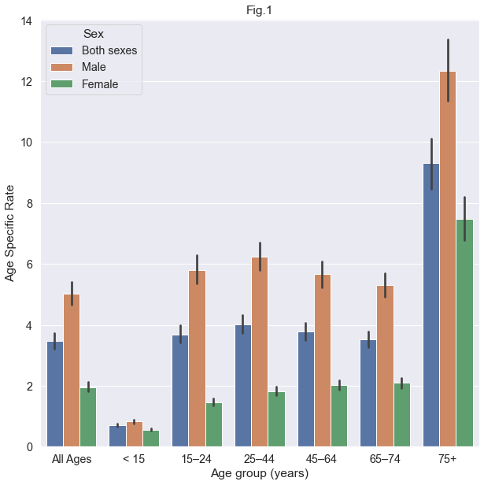

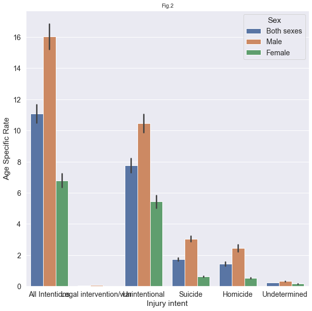

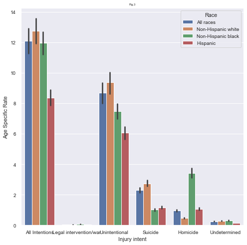

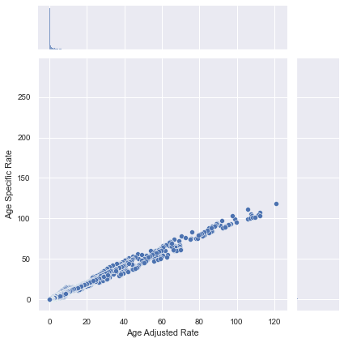

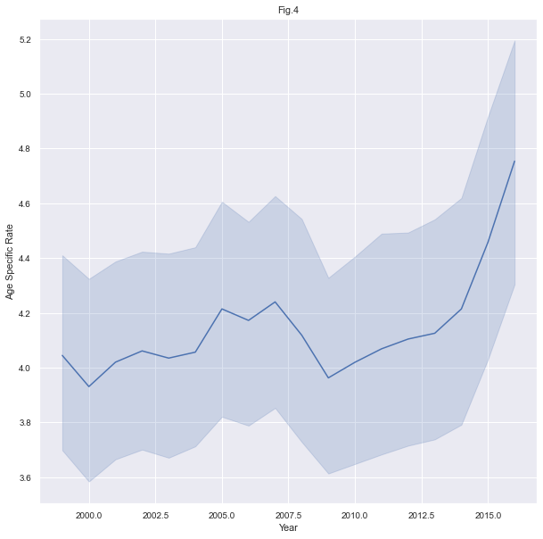

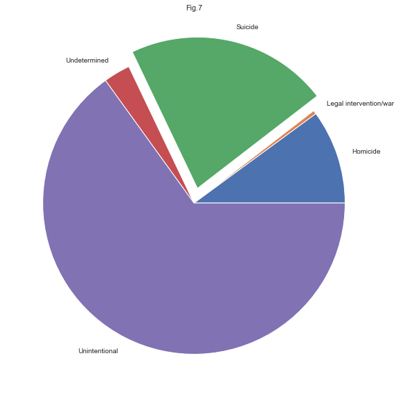

Conclusions

From this data we can conclude the following: 1- Males are more death expected than Females. 2- The most resedent Age Specific Rate are with the age of more than 75 years then, the age range 25 to 44 then the range 15 to 24. 3- The most numbers of homicide victims are from Non-hispanic Black race. While the Non-hispanic white races are having the largest number of suicide deaths. 4- The number of age specific rate is directly correlated with years. There was a decreasing in curve pattern nearly between the years of 2007 and 2009 which perhaps because of the update of population censuses used in 2010. (Read the description in kaggel website). 5- Finally, and unfortunately, Suicide victims are more than homicidal victims and the unintentional victims have the largest number of deaths.